# The rise of ecological network meta-analyses: Problems and prospects - ScienceDirect

## Outline

1. Abstract
2. Keywords
3. Declaration of Competing Interest
4. Acknowledgments
5. Appendix A. Supplementary material
6. References

## Figures (1)

[figure not shown]

## Extras (2)

1. Supplementary material.
2. Supplementary material.

## [Global Ecology and Conservation](https://www.sciencedirect.com/journal/global-ecology-and-conservation)

[Volume 30](https://www.sciencedirect.com/journal/global-ecology-and-conservation/vol/30/suppl/C), October 2021, e01805

# Short Communication The rise of ecological network meta-analyses: Problems and prospects

[ShuangXing](https://www.sciencedirect.com/science/article/pii/S2351989421003553#!)[Tom M.Fayle](https://www.sciencedirect.com/science/article/pii/S2351989421003553#!)

https://doi.org/10.1016/j.gecco.2021.e01805[Get rights and content](https://s100.copyright.com/AppDispatchServlet?publisherName=ELS&contentID=S2351989421003553&orderBeanReset=true)

Under a Creative Commons [license](https://creativecommons.org/licenses/by-nc-nd/4.0/)

Open access

## Abstract

Investigating ecological networks can help us to understand how ecosystems respond to environmental changes. The increasing number of ecological network studies has facilitated the emergence of a body of meta-analyses that aims to generalize geographical patterns of ecological interactions. Here we summarize the status, potential shortcomings, and challenges in meta-analyses of ecological networks. We emphasize the importance of this approach and how it can be developed in the future. This ongoing ecological network meta-analytical approach will continue to generate important insights into existing patterns in global ecological networks and enhance our knowledge of future global change impacts on ecosystems.

## Keywords

Meta-analyses

Ecological network

Species interaction

Latitude

Environmental gradients

Standardization

The complexity and diversity of ecological interaction networks influences the stability and dynamics of ecosystems (Mougi and Kondoh, 2012). Comparing networks across different study systems and environments can reveal geographic patterns in species interactions, and hence identify key ecological and evolutionary drivers of network structure (Pellissier et al., 2018). However, sampling interaction networks at hundreds of individual sites across the world is logistically and financially challenging, and thus is beyond the scope of most research grants (Pellissier et al., 2018). Fortunately, network ecology is becoming a mature discipline, and the number of network datasets collected from individual sites has increased greatly over the past two decades (Heleno et al., 2014) (Fig. 1b). Consequently, there has been a recent rapid increase in meta-analytical studies that collate and compare existing network data to address large-scale network ecology questions (Fig. 1a). Here we describe the challenges and opportunities of using this approach and outline potentially fruitful future research directions. Note that we use the more restricted definition of the term “meta-analysis” referring to collation and re-analysis of primary data from individual network studies, as opposed to recording and analysis of effect sizes from existing publications.

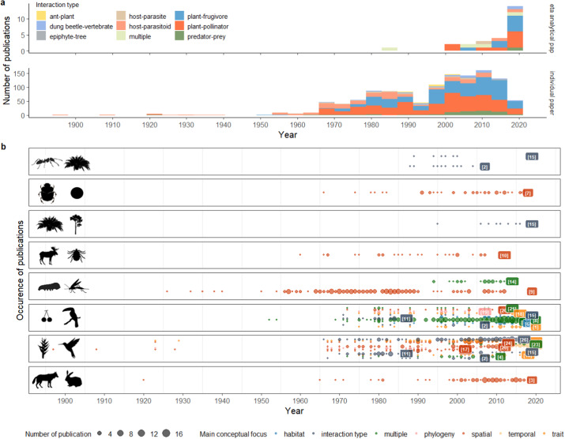

Fig. 1. (a) Frequency of ecological network studies using a meta-analytical approach and the individual studies included in each of those meta-analyses in relation to publication year. In the last three years (2018–2020) there were an average of 4.0 meta-analytical studies per year, whereas in the preceding 18 years (2000–2017) there were only 0.8 studies per year, with one prior to 2000. In total these meta-analyses have collated data from 874 primary data studies published between 1897 and 2020. Note the differing scales of the y-axes. (b) Distribution of individual primary data studies through time for each meta-analysis grouped by interaction type and coded by the major conceptual topic of the study. Illustrations on the left of each panel represent the interaction type for which data were collated (interaction types from the top to the bottom panel: ant-plant; dung beetle-vertebrate; epiphyte-tree; host-parasite; host-parasitoid; plant-frugivore; plant-pollinator; predator-prey). Individual studies used for each meta-analysis are denoted by circular points to the left of that meta-analysis. Colors of the circular points and labels indicate the main conceptual focus of the meta-analysis. Point sizes indicate the number of individual studies published in each year. Each meta-analytical study is denoted by a rounded rectangular point with a reference number (see bibliography in the Supplementary Material). Meta-analyses were collated during ongoing work collating network data for the LifeWebs project ([www.lifewebs.net](http://www.lifewebs.net/); Fayle et al., 2016), supplemented with other published meta-analyses noticed by team members during data collation (For interpretation of the references to color in this figure legend, the reader is referred to the web version of this article).

Network meta-analyses now cover a broad range of interaction types and address various ecological questions (Fig. 1). These studies mainly focus on three fundamental questions: (1) How does specialization vary with latitude? (2) How do networks respond to local species extinction? (3) How do traits and evolutionary history influence network structure? These synthetic studies have found little support for consistent patterns in network structure between interaction types, or even within the same interaction type. One key prediction is that higher specialization in the tropics should be associated with higher species richness. Although this has been confirmed by some studies on plant-pollinator (Olesen and Jordano, 2002) and predator-prey (Ceron et al., 2019) networks, other studies find no latitudinal patterns (Frank et al., 2018) or even that tropical specialization is lower (Dalsgaard et al., 2017). Such inconsistent latitudinal patterns in specialization indicate that complex mechanisms shape network structure across space. For example, differing consumer responses to resource availability within an interaction type may contribute to the latitudinal patterns of plant-frugivore (Dalsgaard et al., 2017) and dung beetle-vertebrate (Frank et al., 2018) interactions. In addition, evidence is accumulating that species traits (Sonne et al., 2020), the presence of introduced species (Fricke and Svenning, 2020), phenology (Sonne et al., 2020) and spatial scale (Galiana et al., 2019) can also influence network patterns.

These emerging meta-analytical studies have significantly enhanced our understanding of drivers of ecological network structure in three ways that would be highly challenging using only individual studies. First, this approach greatly facilitates exploration of network structure along large spatial (Olesen and Jordano, 2002) and temporal gradients (Burkle et al., 2013). Second, integrating information across a broader [phylogenetic](https://www.sciencedirect.com/topics/earth-and-planetary-sciences/phylogenetics) and functional range of species can reveal key biotic and abiotic mechanisms explaining network structure such as biological traits (Sonne et al., 2020), [climatic factors](https://www.sciencedirect.com/topics/agricultural-and-biological-sciences/climatic-factors) and evolutionary processes (Schleuning et al., 2014). This approach involves integrating network data from individual studies with other databases such as those including functional traits and climate. Third, network meta-analysis facilitates comparison among different interaction types (e.g. mutualistic vs antagonistic interaction) along [environmental gradients](https://www.sciencedirect.com/topics/earth-and-planetary-sciences/environmental-gradient) (Rohr and Bascompte, 2015). Moreover, construction of multi-layer networks (Pilosof et al., 2017) and meta-networks (Fricke and Svenning, 2020) from multiple individual datasets can potentially enable more accurate prediction of ecosystem stability and resilience in response to turnovers in species and environments (Fricke and Svenning, 2020).

Despite these advances, there remain challenges in implementing this approach. These can be divided into those that can be addressed during initial data collection, and those that need to be addressed by the researchers conducting the meta-analysis. Relating to the former category, a significant amount of data is available only as binary networks. This necessitates either use of smaller, interaction frequency only datasets, or loss of information through conversion of these datasets into presence-absence data. Hence, where feasible, field ecologists should aim to collect quantitative information on species interactions. Furthermore, published metadata should be as comprehensive as possible, including full description of field methods, along with any relevant environmental field data for the site.

Challenges that need to be addressed or at least to be acknowledged by the researcher conducting the meta-analysis include: (1) The fact that the ecological importance of the interaction is not necessarily captured, even for datasets recording interaction frequency (Blüthgen et al., 2008). This functional importance of species in networks is rarely assessed, although measurement of functional traits can help in this respect (Sonne et al., 2020); (2) Variation in network size between studies can relate either to real variation in networks, or to variation in sampling effort. This is of concern because sampling effort may also generate bias in some metrics of network structure (Blüthgen et al., 2008). This can best be accounted for where sampling intensity is recorded, and comparable sampling methods are used between studies, although rarefaction of network data may also help overcome this problem. Estimates of total numbers of interactions in an network can also be made using similar tools to those used for species richness (Chacoff et al., 2012), hence allowing interaction sampling completeness to be estimated; (3) Older datasets often have out of date taxonomy, making comparisons with current datasets challenging, although updating older taxonomy can now be done automatically using an R package *taxadb* for some groups (Norman et al., 2020); (4) There can be considerable variation in researcher definitions of interaction type and taxonomic/functional resolution of sampling, necessitating pruning or exclusion of some datasets. Placing networks within a [phylogenetic](https://www.sciencedirect.com/topics/earth-and-planetary-sciences/phylogenetics) context can be a useful approach for addressing this issue. For example, applying a framework that explicitly accounts for phylogenetic similarity (and other measures of similarity, such as functional traits; see above) can be a useful tool to consider the ecological and evolutionary influences on network structure (Jorge et al., 2014); (5) Often it is necessary to account for spatial and temporal autocorrelation, where this is not the main target of the investigation, for example by modeling metrics of network structure using Moran's I (Ohlsson and Eklöf, 2020). (6) Finally, the high level of noise generated by the variation described above probably precludes the use of a meta-analytical approach for detecting subtle changes in network structure, such as those resulting from current levels of climate change. However, more dramatic changes in structure, such as those resulting from land-use change, should still be detectable.

Looking forward, creation of standardized guidelines for collation of network data and unification of the various existing global databases will greatly enhance comparability of collated data thus facilitating future network meta-analyses (Poisot et al., 2021). We predict that the ongoing rapid adoption of obligatory data archiving as a condition for publication will result in further increases in the numbers of datasets available for collation. Trait databases and published [phylogenies](https://www.sciencedirect.com/topics/earth-and-planetary-sciences/phylogeny) cover an increasingly large proportion of species, particularly for well-known groups such as trees and vertebrates, which will allow exploration of functional and [phylogenetic](https://www.sciencedirect.com/topics/earth-and-planetary-sciences/phylogenetics) drivers of network structure. Furthermore, as network studies cover an ever-greater proportion of life on earth, opportunities will arise for integration of these network data into General Ecosystems Models (GEMs), allowing creation of dynamic network models at global scales (Flores et al., 2019). Despite the challenges in integrating network data from existing studies, we envisage that meta-analyses of network data will continue to provide important insights into network ecology and ecosystem functioning.

## Declaration of Competing Interest

The authors declare that they have no known competing financial interests or personal relationships that could have appeared to influence the work reported in this paper.

## Acknowledgments

S.X and T.M.F were funded by the Czech Science Foundation, Czech Republic, Grant ID: 21-06446S. Neither author declares any [conflict of interest](https://www.sciencedirect.com/topics/earth-and-planetary-sciences/conflict-of-interests).

## Appendix A. Supplementary material

[Download : Download Word document (16KB)](https://ars.els-cdn.com/content/image/1-s2.0-S2351989421003553-mmc1.docx)

Supplementary material.

.

[Download : Download Comma Separated Value file (10KB)](https://ars.els-cdn.com/content/image/1-s2.0-S2351989421003553-mmc2.csv)

Supplementary material.

.

## References

**Blüthgen et al., 2008**

N. Blüthgen, J. Fründ, D.P. Vázquez, F. Menzel

**What do interaction network metrics tell us about specialization and biological traits**

Ecology, 89 (12) (2008), pp. 3387-3399

[CrossRef](https://doi.org/10.1890/07-2121.1)[View Record in Scopus](https://www.scopus.com/inward/record.url?eid=2-s2.0-57549118139&partnerID=10&rel=R3.0.0)Google Scholar

**Burkle et al., 2013**

L.A. Burkle, J.C. Marlin, T.M. Knight

**Plant-pollinator interactions over 120 years: loss of species, co-occurrence, and function**

Science, 339 (2013), 10.1126/science.1232728

Google Scholar

**Ceron et al., 2019**

K. Ceron, L.G.R. Oliveira-Santos, C.S. Souza, D.O. Mesquita, F.L.S. Caldas, A.C. Araujo, D.J. Santana

**Global patterns in anuran–prey networks: structure mediated by latitude**

Oikos, 128 (2019), pp. 1537-1548, 10.1111/oik.06621

[View Record in Scopus](https://www.scopus.com/inward/record.url?eid=2-s2.0-85074279090&partnerID=10&rel=R3.0.0)[Google Scholar](https://scholar.google.com/scholar?q=Global%20patterns%20in%20anuranprey%20networks:%20structure%20mediated%20by%20latitude)

**Chacoff et al., 2012**

N.P. Chacoff, D.P. Vázquez, S.B. Lomáscolo, E.L. Stevani, J. Dorado, B. Padrón

**Evaluating sampling completeness in a desert plant–pollinator network**

J. Anim. Ecol., 81 (1) (2012), pp. 190-200

[CrossRef](https://doi.org/10.1111/j.1365-2656.2011.01883.x)[View Record in Scopus](https://www.scopus.com/inward/record.url?eid=2-s2.0-83155172435&partnerID=10&rel=R3.0.0)[Google Scholar](https://scholar.google.com/scholar?q=Evaluating%20sampling%20completeness%20in%20a%20desert%20plantpollinator%20network)

**Dalsgaard et al., 2017**

B. Dalsgaard, M. Schleuning, P.K. Maruyama, D.M. Dehling, J. Sonne, J. Vizentin-Bugoni, C. Rahbek

**Opposed latitudinal patterns of network-derived and dietary specialization in avian plant-frugivore interaction systems**

Ecography, 40 (12) (2017), pp. 1395-1401, 10.1111/ecog.02604

[View Record in Scopus](https://www.scopus.com/inward/record.url?eid=2-s2.0-85012159472&partnerID=10&rel=R3.0.0)Google Scholar

**Flores et al., 2019**

C. Flores, S. Kortsch, D. Tittensor, M. Harfoot, D. Purves

**Food webs: insights from a general ecosystem model**

BioRxiv (2019), 10.1101/588665

Google Scholar

**Frank et al., 2018**

K. Frank, F.-T. Krell, E.M. Slade, E.H. Raine, L.Y. Chiew, T. Schmitt, N. Blüthgen

**Global dung webs: high trophic generalism of dung beetles along the latitudinal diversity gradient**

Ecol. Lett., 21 (8) (2018), pp. 1229-1236, 10.1111/ele.13095

[View Record in Scopus](https://www.scopus.com/inward/record.url?eid=2-s2.0-85049846600&partnerID=10&rel=R3.0.0)Google Scholar

**Fricke and Svenning, 2020**

E.C. Fricke, J.C. Svenning

**Accelerating homogenization of the global plant–frugivore meta-network**

Nature, 585 (2020), pp. 74-78, 10.1038/s41586-020-2640-y

[Google Scholar](https://scholar.google.com/scholar?q=Accelerating%20homogenization%20of%20the%20global%20plantfrugivore%20meta-network)

**Galiana et al., 2019**

N. Galiana, B.A. Hawkins, J.M. Montoya

**The geographical variation of network structure is scale dependent: understanding the biotic specialization of host–parasitoid networks**

Ecography, 42 (6) (2019), pp. 1175-1187, 10.1111/ecog.03684

[View Record in Scopus](https://www.scopus.com/inward/record.url?eid=2-s2.0-85063381171&partnerID=10&rel=R3.0.0)[Google Scholar](https://scholar.google.com/scholar?q=The%20geographical%20variation%20of%20network%20structure%20is%20scale%20dependent:%20understanding%20the%20biotic%20specialization%20of%20hostparasitoid%20networks)

**Heleno et al., 2014**

R. Heleno, C. Garcia, P. Jordano, A. Traveset, J.M. Gómez, N. Blüthgen, J.M. Olesen

**Ecological networks: delving into the architecture of biodiversity**

Biol. Lett., 10 (1) (2014), Article 20131000, 10.1098/RSBL.2013.1000

[View Record in Scopus](https://www.scopus.com/inward/record.url?eid=2-s2.0-84893869784&partnerID=10&rel=R3.0.0)Google Scholar

**Jorge et al., 2014**

L.R. Jorge, P.I. Prado, M. Almeida‐Neto, T.M. Lewinsohn

**An integrated framework to improve the concept of resource specialisation**

Ecol. Lett., 17 (11) (2014), pp. 1341-1350, 10.1111/ele.12347

[View Record in Scopus](https://www.scopus.com/inward/record.url?eid=2-s2.0-84907809776&partnerID=10&rel=R3.0.0)Google Scholar

**Mougi and Kondoh, 2012**

A. Mougi, M. Kondoh

**Diversity of interaction types and ecological community stability**

Science, 337 (6092) (2012), pp. 349-351, 10.1126/science.1220529

[View Record in Scopus](https://www.scopus.com/inward/record.url?eid=2-s2.0-84863995610&partnerID=10&rel=R3.0.0)[Google Scholar](https://scholar.google.com/scholar_lookup?title=Diversity%20of%20interaction%20types%20and%20ecological%20community%20stability&publication_year=2012&author=A.%20Mougi&author=M.%20Kondoh)

**Norman et al., 2020**

K.E.A. Norman, S. Chamberlain, C. Boettiger

**taxadb: a high-performance local taxonomic database interface**

Methods Ecol. Evol., 11 (2020), pp. 1153-1159, 10.1111/2041-210X.13440

[View Record in Scopus](https://www.scopus.com/inward/record.url?eid=2-s2.0-85088840109&partnerID=10&rel=R3.0.0)Google Scholar

**Ohlsson and Eklöf, 2020**

M. Ohlsson, A. Eklöf

**Spatial resolution and location impact group structure in a marine food web**

Ecol. Lett., 23 (10) (2020), pp. 1451-1459, 10.1111/ele.13567

[View Record in Scopus](https://www.scopus.com/inward/record.url?eid=2-s2.0-85087706540&partnerID=10&rel=R3.0.0)Google Scholar

**Olesen and Jordano, 2002**

J.M. Olesen, P. Jordano

**Geographic patterns in plant-pollinator mutualistic networks**

Ecology (2002), 10.1890/0012-9658(2002)083[2416:GPIPPM]2.0.CO;2

[Google Scholar](https://scholar.google.com/scholar_lookup?title=Geographic%20patterns%20in%20plant-pollinator%20mutualistic%20networks&publication_year=2002&author=J.M.%20Olesen&author=P.%20Jordano)

**Pellissier et al., 2018**

L. Pellissier, C. Albouy, J. Bascompte, N. Farwig, C. Graham, M. Loreau, D. Gravel

**Comparing species interaction networks along environmental gradients**

Biol. Rev. Camb. Philos. Soc., 93 (2018), pp. 785-800, 10.1111/brv.12366

[View Record in Scopus](https://www.scopus.com/inward/record.url?eid=2-s2.0-85043336385&partnerID=10&rel=R3.0.0)Google Scholar

**Pilosof et al., 2017**

S. Pilosof, M.A. Porter, M. Pascual, S. Kéfi

**The multilayer nature of ecological networks**

Nat. Ecol. Evol., 1 (4) (2017), pp. 1-9, 10.1038/s41559-017-0101

[View Record in Scopus](https://www.scopus.com/inward/record.url?eid=2-s2.0-85104185346&partnerID=10&rel=R3.0.0)[Google Scholar](https://scholar.google.com/scholar_lookup?title=The%20multilayer%20nature%20of%20ecological%20networks&publication_year=2017&author=S.%20Pilosof&author=M.A.%20Porter&author=M.%20Pascual&author=S.%20K%C3%A9fi)

**Poisot et al., 2021**

T. Poisot, G. Bergeron, K. Cazelles, T. Dallas, D. Gravel, A. MacDonald, S. Vissault

**Global knowledge gaps in species interaction networks data**

J. Biogeogr., 48 (2021), pp. 1552-1563, 10.1111/jbi.14127

[View Record in Scopus](https://www.scopus.com/inward/record.url?eid=2-s2.0-85105412288&partnerID=10&rel=R3.0.0)Google Scholar

**Rohr and Bascompte, 2015**

R.P. Rohr, J. Bascompte

**Components of phylogenetic signal in antagonistic and mutualistic networks**

Am. Nat., 184 (5) (2015), pp. 556-564, 10.1086/678234

[Google Scholar](https://scholar.google.com/scholar_lookup?title=Components%20of%20phylogenetic%20signal%20in%20antagonistic%20and%20mutualistic%20networks&publication_year=2015&author=R.P.%20Rohr&author=J.%20Bascompte)

**Schleuning et al., 2014**

M. Schleuning, L. Ingmann, R. Strauß, S.A. Fritz, B. Dalsgaard, D. Matthias Dehling, C.F. Dormann

**Ecological, historical and evolutionary determinants of modularity in weighted seed-dispersal networks**

Ecol. Lett., 17 (2014), 10.1111/ele.12245

Google Scholar

**Sonne et al., 2020**

J. Sonne, J. Vizentin-Bugoni, P.K. Maruyama, A.C. Araujo, E. Chávez-González, A.G. Coelho, B. Dalsgaard

**Ecological mechanisms explaining interactions within plant–hummingbird networks: morphological matching increases towards lower latitudes**

Proc. Biol. Sci., 287 (1922) (2020), Article 20192873, 10.1098/rspb.2019.2873

[View Record in Scopus](https://www.scopus.com/inward/record.url?eid=2-s2.0-85081656317&partnerID=10&rel=R3.0.0)[Google Scholar](https://scholar.google.com/scholar?q=Ecological%20mechanisms%20explaining%20interactions%20within%20planthummingbird%20networks:%20morphological%20matching%20increases%20towards%20lower%20latitudes)

**Fayle et al., 2016**

T.M. Fayle, K. Sam, A. Humlova, L. Cagnolo, V. Novotny

**The LifeWebs project: A call for data describing plant-herbivore interaction networks**

Front. Biogeogr., 8 (4) (2016)

Google Scholar

© 2021 The Author(s). Published by Elsevier B.V.

Captures

Social Media